# Python - Day 2

### 0.1 Introduction

Welcome to the second day of **Intro to Python**. In today’s session we will cover:

- Summary statistics  
  ** Measure of spread  
  ** Measure central tendency
- Aggregate data
- Dealing with missing values
- Basic data visualisation

We initiated our data exploration by employing the Pandas library, a fundamental tool for data manipulation and analysis in Python.

We will first load package and data.

### 0.2 Loading package and data

```python
import pandas as pd
```

```python
data= pd.read_csv("ames.csv")
```

Initially, let’s examine the dataset overview. The `data.info()` gives us an overview of the dataset, including the number of non-null entries and data types of each column.

```python
data.info()
```

```
<class 'pandas.core.frame.DataFrame'>
RangeIndex: 2930 entries, 0 to 2929
Data columns (total 81 columns):
 #   Column           Non-Null Count  Dtype
---  ------           --------------  -----
 0   Order            2930 non-null   int64
 1   MS SubClass      2930 non-null   int64
 2   MS Zoning        2930 non-null   object
 3   Lot Frontage     2440 non-null   float64
 4   Lot Area         2930 non-null   int64
 5   Street           2930 non-null   object
 6   Alley            198 non-null    object
 7   Lot Shape        2930 non-null   object
 8   Land Contour     2930 non-null   object
 9   Utilities        2930 non-null   object
```

[output cut: 73 more lines]

### 0.3 Summary Statistics

Now we will explore **summary statistics** to gain an initial understanding of our dataset.

**Summary Statistics:** It provides a concise summary of the main aspects of a dataset, including measures of central tendency (such as mean, median, and mode) and measures of dispersion (such as range, variance, and standard deviation).

`data.describe()` provides statistical insights into numerical columns, offering metrics like mean (average), standard deviation (a measure of data spread), and quartiles (dividing the data into four parts).

```python
data.describe()
```

|  | Order | MS SubClass | Lot Frontage | Lot Area | Overall Qual | Overall Cond | Year Built | Year Remod/Add | Mas Vnr Area | BsmtFin SF 1 | ... | Wood Deck SF | Open Porch SF | Enclosed Porch | 3Ssn Porch | Screen Porch | Pool Area | Misc Val | Mo Sold | Yr Sold | SalePrice |
| --- | --- | --- | --- | --- | --- | --- | --- | --- | --- | --- | --- | --- | --- | --- | --- | --- | --- | --- | --- | --- | --- |
| count | 2930.00000 | 2930.000000 | 2440.000000 | 2930.000000 | 2930.000000 | 2930.000000 | 2930.000000 | 2930.000000 | 2907.000000 | 2929.000000 | ... | 2930.000000 | 2930.000000 | 2930.000000 | 2930.000000 | 2930.000000 | 2930.000000 | 2930.000000 | 2930.000000 | 2930.000000 | 2930.000000 |
| mean | 1465.50000 | 57.387372 | 69.224590 | 10147.921843 | 6.094881 | 5.563140 | 1971.356314 | 1984.266553 | 101.896801 | 442.629566 | ... | 93.751877 | 47.533447 | 23.011604 | 2.592491 | 16.002048 | 2.243345 | 50.635154 | 6.216041 | 2007.790444 | 180796.060068 |
| std | 845.96247 | 42.638025 | 23.365335 | 7880.017759 | 1.411026 | 1.111537 | 30.245361 | 20.860286 | 179.112611 | 455.590839 | ... | 126.361562 | 67.483400 | 64.139059 | 25.141331 | 56.087370 | 35.597181 | 566.344288 | 2.714492 | 1.316613 | 79886.692357 |
| min | 1.00000 | 20.000000 | 21.000000 | 1300.000000 | 1.000000 | 1.000000 | 1872.000000 | 1950.000000 | 0.000000 | 0.000000 | ... | 0.000000 | 0.000000 | 0.000000 | 0.000000 | 0.000000 | 0.000000 | 0.000000 | 1.000000 | 2006.000000 | 12789.000000 |
| 25% | 733.25000 | 20.000000 | 58.000000 | 7440.250000 | 5.000000 | 5.000000 | 1954.000000 | 1965.000000 | 0.000000 | 0.000000 | ... | 0.000000 | 0.000000 | 0.000000 | 0.000000 | 0.000000 | 0.000000 | 0.000000 | 4.000000 | 2007.000000 | 129500.000000 |
| 50% | 1465.50000 | 50.000000 | 68.000000 | 9436.500000 | 6.000000 | 5.000000 | 1973.000000 | 1993.000000 | 0.000000 | 370.000000 | ... | 0.000000 | 27.000000 | 0.000000 | 0.000000 | 0.000000 | 0.000000 | 0.000000 | 6.000000 | 2008.000000 | 160000.000000 |
| 75% | 2197.75000 | 70.000000 | 80.000000 | 11555.250000 | 7.000000 | 6.000000 | 2001.000000 | 2004.000000 | 164.000000 | 734.000000 | ... | 168.000000 | 70.000000 | 0.000000 | 0.000000 | 0.000000 | 0.000000 | 0.000000 | 8.000000 | 2009.000000 | 213500.000000 |
| max | 2930.00000 | 190.000000 | 313.000000 | 215245.000000 | 10.000000 | 9.000000 | 2010.000000 | 2010.000000 | 1600.000000 | 5644.000000 | ... | 1424.000000 | 742.000000 | 1012.000000 | 508.000000 | 576.000000 | 800.000000 | 17000.000000 | 12.000000 | 2010.000000 | 755000.000000 |

8 rows × 38 columns

To gain insights into object or text data, an additional parameter is required. By using `data.describe(include="object")`we can obtain information about categorical columns, including unique values, the most common value, and its frequency.

```python
data.describe(include="object")
```

|  | MS Zoning | Street | Alley | Lot Shape | Land Contour | Utilities | Lot Config | Land Slope | Neighborhood | Condition 1 | ... | Garage Type | Garage Finish | Garage Qual | Garage Cond | Paved Drive | Pool QC | Fence | Misc Feature | Sale Type | Sale Condition |
| --- | --- | --- | --- | --- | --- | --- | --- | --- | --- | --- | --- | --- | --- | --- | --- | --- | --- | --- | --- | --- | --- |
| count | 2930 | 2930 | 198 | 2930 | 2930 | 2930 | 2930 | 2930 | 2930 | 2930 | ... | 2773 | 2771 | 2771 | 2771 | 2930 | 13 | 572 | 106 | 2930 | 2930 |
| unique | 7 | 2 | 2 | 4 | 4 | 3 | 5 | 3 | 28 | 9 | ... | 6 | 3 | 5 | 5 | 3 | 4 | 4 | 5 | 10 | 6 |
| top | RL | Pave | Grvl | Reg | Lvl | AllPub | Inside | Gtl | NAmes | Norm | ... | Attchd | Unf | TA | TA | Y | Ex | MnPrv | Shed | WD | Normal |
| freq | 2273 | 2918 | 120 | 1859 | 2633 | 2927 | 2140 | 2789 | 443 | 2522 | ... | 1731 | 1231 | 2615 | 2665 | 2652 | 4 | 330 | 95 | 2536 | 2413 |

4 rows × 43 columns

### 0.4 Measure of central tendency

Measures of central tendency provides information about the “center” or typical value of a dataset. We will delve deeper into understanding the distribution and variability of our data by calculating (mean, median) for the “MS SubClass” column.  
- **Mean:** The mean is the average value of a dataset .

- **Median:** The median is the middle value of a dataset when it is sorted in ascending order. It is less affected by extreme values than the mean.

```python
data["MS SubClass"].mean()
#This gives us sense of where most data points cluster around
```

```
57.38737201365188
```

```python
data["MS SubClass"].median()
```

```
50.0
```

### 0.5 Measure dispersion

This describes how spread out or scattered a set of data is.It provides information about the variability or diversity of the data points in the dataset.

- **Range:** The range is the difference between the maximum and minimum values in a dataset, providing insight into the spread of the data.
- **Variance:** Variance measures how much the values in a dataset vary. It is the average of the squared differences from the Mean.
- **Standard Deviation:** Standard deviation quantifies the amount of variation or dispersion of a set of values. It is the square root of the variance.

We will look at the dispersion for the `Ms SubClass` column

```python
ms_subclass_range = data["MS SubClass"].max()- data["MS SubClass"].min()
ms_subclass_range
```

```
170
```

```python
data["MS SubClass"].var()
```

```
1818.0011378506483
```

```python
data["MS SubClass"].std()
```

```
42.6380245538023
```

### 0.6 Missing Values

When analyzing data, encountering missing values is a common scenario that requires careful management. Addressing these gaps is crucial before delving into the analysis process.

### 0.7 **Approaches to Handle Missing Data**

#### 0.7.1 Imputation

- This involves filling in missing columns with estimated values based on the available data
- Different approach available from simple to complex

#### 0.7.2 Deletion

- This involves deleting an entire record (row) if a value is missing
- Data can be reduced significantly
- If values are not missing at random, can introduce significant bias

#### 0.7.3 Identifying missing data

Utilizing the .isna()or .isnull() method, we can identify missing values in the dataset.data.isnull().sum() provides a summary of missing values.

```python
data.isnull()
```

|  | Order | MS SubClass | MS Zoning | Lot Frontage | Lot Area | Street | Alley | Lot Shape | Land Contour | Utilities | ... | Pool Area | Pool QC | Fence | Misc Feature | Misc Val | Mo Sold | Yr Sold | Sale Type | Sale Condition | SalePrice |
| --- | --- | --- | --- | --- | --- | --- | --- | --- | --- | --- | --- | --- | --- | --- | --- | --- | --- | --- | --- | --- | --- |
| 0 | False | False | False | False | False | False | True | False | False | False | ... | False | True | True | True | False | False | False | False | False | False |
| 1 | False | False | False | False | False | False | True | False | False | False | ... | False | True | False | True | False | False | False | False | False | False |
| 2 | False | False | False | False | False | False | True | False | False | False | ... | False | True | True | False | False | False | False | False | False | False |
| 3 | False | False | False | False | False | False | True | False | False | False | ... | False | True | True | True | False | False | False | False | False | False |
| 4 | False | False | False | False | False | False | True | False | False | False | ... | False | True | False | True | False | False | False | False | False | False |
| ... | ... | ... | ... | ... | ... | ... | ... | ... | ... | ... | ... | ... | ... | ... | ... | ... | ... | ... | ... | ... | ... |
| 2925 | False | False | False | False | False | False | True | False | False | False | ... | False | True | False | True | False | False | False | False | False | False |
| 2926 | False | False | False | True | False | False | True | False | False | False | ... | False | True | False | True | False | False | False | False | False | False |
| 2927 | False | False | False | False | False | False | True | False | False | False | ... | False | True | False | False | False | False | False | False | False | False |
| 2928 | False | False | False | False | False | False | True | False | False | False | ... | False | True | True | True | False | False | False | False | False | False |
| 2929 | False | False | False | False | False | False | True | False | False | False | ... | False | True | True | True | False | False | False | False | False | False |

2930 rows × 81 columns

```python
data.isnull().sum()
```

```
Order               0
MS SubClass         0
MS Zoning           0
Lot Frontage      490
Lot Area            0
                 ...
Mo Sold             0
Yr Sold             0
Sale Type           0
Sale Condition      0
SalePrice           0
Length: 81, dtype: int64
```

After identifying missing values, it is often crucial to focus on columns with a substantial amount of missing data. We will create a variable called `filter_columns`where we will store columns that contain more than one missing value. We will sort this by descending order. So we will have high number of missing value on top.

```python
missing_values = data.isna().sum()
filter_columns = missing_values[(missing_values >1)].sort_values(ascending=False)
```

```python
filter_columns
```

```
Pool QC           2917
Misc Feature      2824
Alley             2732
Fence             2358
Fireplace Qu      1422
Lot Frontage       490
Garage Yr Blt      159
Garage Finish      159
Garage Qual        159
Garage Cond        159
Garage Type        157
Bsmt Exposure       83
BsmtFin Type 2      81
BsmtFin Type 1      80
Bsmt Cond           80
Bsmt Qual           80
Mas Vnr Area        23
Mas Vnr Type        23
Bsmt Full Bath       2
Bsmt Half Bath       2
dtype: int64
```

#### 0.7.4 Imputation

Filling missing values with statistics: We can fill missing value with summary statistics such as mean, median, mode among others.

Median is often used to fill missing value (i) it is not influenced by extreme values or outliers in data. (ii) it helps to preserve the overall distribution of the data.

We will impute missing value in Mas Vnr Area column with mean value. To do this, we will first create a variable called `mean_value_mva`where we will calculate the average value using the `.mean` method. The `round()` function is used to round the mean value to two decimal place for consistency.

```python
# Filling in missing value

mean_value_mva= round (data["Mas Vnr Area"].mean(), ndigits=2)
```

The `fillna`method replaces the missing value in the `Mas Vnr Area` column with this calculated mean. Imputation helps maintain the dataset’s overall statistical properties. The `inplace=True` ensures that the change is applied directly to the dataset.

```python
data["Mas Vnr Area"].fillna(mean_value_mva, inplace=True)
```

Now we will look at the `Mas Vnr Area` column to ensure missing value has been handled.

```python
data["Mas Vnr Area"].isna().sum()
```

```
0
```

#### 0.7.5 Deletion

Sometimes, certain columns might have a large number if missing values or might not be relevant to the analysis.In such cases, dropping the entire columns is a viable option. Here the `Pool QC` column is removed from the dataset using the `.drop()`method, The `axis=1` parameter specifies that the operation is performed on columns.

```python
data.drop("Pool QC", axis=1, inplace=True)
```

```python
data.info()
```

```
<class 'pandas.core.frame.DataFrame'>
RangeIndex: 2930 entries, 0 to 2929
Data columns (total 80 columns):
 #   Column           Non-Null Count  Dtype
---  ------           --------------  -----
 0   Order            2930 non-null   int64
 1   MS SubClass      2930 non-null   int64
 2   MS Zoning        2930 non-null   object
 3   Lot Frontage     2440 non-null   float64
 4   Lot Area         2930 non-null   int64
 5   Street           2930 non-null   object
 6   Alley            198 non-null    object
 7   Lot Shape        2930 non-null   object
 8   Land Contour     2930 non-null   object
 9   Utilities        2930 non-null   object
```

[output cut: 72 more lines]

### 0.8 Data Visualisation

Visualization is a powerful tool in data analysis, allowing us to grasp patterns and trends more intuitively. We used the Matplotlib library to create a histogram, a common visualization for understanding the distribution of a dataset.

- **Histogram:** A histogram is a graphical representation of the distribution of numerical data. It is an estimate of the probability distribution of a continuous variable.

```python
import matplotlib.pyplot as plt
```

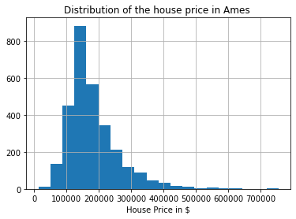

```python
data["SalePrice"].hist(bins=20)
plt.xlabel("House Price in $")
plt.title("Distribution of the house price in Ames ");
```

The histogram illustrates the frequency of house prices in the dataset, offering an immediate visual sense of how prices are distributed.

```python
numerical_data = data.select_dtypes("number") # int64   # float64
numerical_data.info()
```

```
<class 'pandas.core.frame.DataFrame'>
RangeIndex: 2930 entries, 0 to 2929
Data columns (total 38 columns):
 #   Column           Non-Null Count  Dtype
---  ------           --------------  -----
 0   Order            2930 non-null   int64
 1   MS SubClass      2930 non-null   int64
 2   Lot Frontage     2440 non-null   float64
 3   Lot Area         2930 non-null   int64
 4   Overall Qual     2930 non-null   int64
 5   Overall Cond     2930 non-null   int64
 6   Year Built       2930 non-null   int64
 7   Year Remod/Add   2930 non-null   int64
 8   Mas Vnr Area     2930 non-null   float64
 9   BsmtFin SF 1     2929 non-null   float64
```

[output cut: 30 more lines]

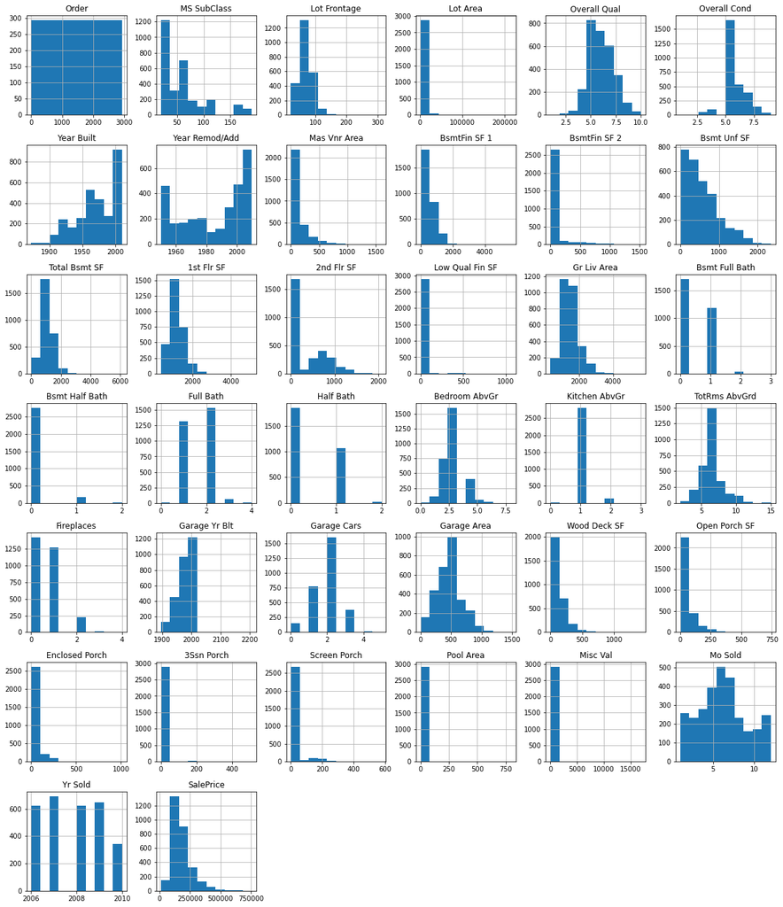

```python
numerical_data.hist(figsize=(20,24))
plt.subplots_adjust()
```

#### 0.8.1 Data Visualization - Mean Price by Neighborhood

Lastly, we will employe data visualization techniques to explore relationships within the dataset. We calculate the mean house price for each neighborhood and represented the results using a horizontal bar chart.

- **Bar Chart:** A bar chart (or bar graph) presents categorical data with rectangular bars. The length of each bar is proportional to the value it represents.

```python
# calculate mean price by  neighbourhood
mean_price_by_neighbourhood = data.groupby('Neighborhood')['SalePrice'].mean()
```

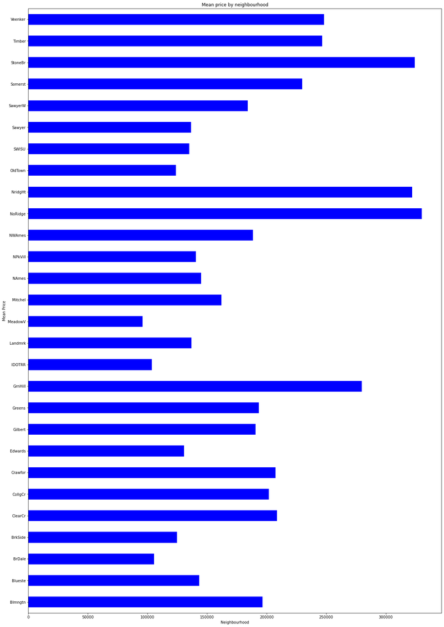

```python
mean_price_by_neighbourhood.plot(kind="barh",rot=0, color="blue", figsize=(20,30))
plt.xlabel("Neighbourhood")
plt.ylabel("Mean Price")
plt.title("Mean price by neighbourhood")
plt.show()
```

This visualization offers insights into how house prices vary across different neighborhoods, providing valuable information for real estate analysis.

In summary, this session provided a comprehensive overview of essential data analysis techniques, from data loading and exploration to summary statistics, handling missing data and data visualisation. These foundational skills are indispensable for anyone working with real-world datasets, enabling them to uncover patters, make informed decision, and draw meaningful conclusions from data.